# Commercial Goals: Receipts Program

Utilizing Synthetic Controls to Baseline Projected Performance

Insights and Analytics | Last Updated: 30 January, 2022

# Top Line

We built a forecast model to set a useful baseline for the business to build from. The business owner for this metric will ultimately set where were they want the business goal to land.

4 different forecasting models were applied, and are displayed below. These different models allow us to understand the potential impact of different scenarios.

|  | 2017 | 2018 | 2019 | 2020 | 2021 | 2022<sup>1</sup> | 2022FC_M1 | 2022FC_M2 | 2022FC_M3 | 2022FC_M4 | Business Goal |
| --- | --- | --- | --- | --- | --- | --- | --- | --- | --- | --- | --- |
| Jan | 24.9K | 27.8K | 40.0K | 38.2K | 21.6K | 16.5K | 25.8K | 30.0K | 34.5K | 27.4K | TBD |
| Feb | 29.7K | 35.0K | 32.2K | 47.3K | 20.4K | - | 24.8K | 29.2K | 32.0K | 26.0K | TBD |
| Mar | 43.6K | 46.6K | 43.5K | 22.2K | 42.4K | - | 32.6K | 37.9K | 42.3K | 36.3K | TBD |
| Apr | 48.9K | 44.5K | 43.1K | 0.1K | 34.5K | - | 30.9K | 36.7K | 45.2K | 40.0K | TBD |
| May | 52.8K | 48.9K | 43.5K | 9.9K | 34.4K | - | 30.0K | 36.8K | 45.9K | 41.1K | TBD |
| Jun | 43.0K | 50.6K | 53.7K | 27.5K | 32.8K | - | 33.5K | 40.7K | 47.0K | 42.9K | TBD |
| Jul | 54.9K | 59.2K | 54.1K | 38.3K | 43.6K | - | 39.9K | 48.0K | 52.8K | 49.1K | TBD |
| Aug | 59.0K | 65.9K | 61.3K | 50.8K | 43.5K | - | 45.1K | 53.7K | 57.8K | 54.5K | TBD |
| Sep | 45.3K | 44.5K | 38.2K | 37.2K | 32.3K | - | 29.5K | 38.4K | 40.7K | 38.0K | TBD |
| Oct | 43.6K | 40.4K | 41.3K | 35.5K | 34.3K | - | 29.8K | 39.4K | 41.5K | 39.1K | TBD |
| Nov | 62.1K | 59.3K | 55.6K | 47.2K | 45.0K | - | 40.2K | 49.9K | 52.6K | 50.7K | TBD |
| Dec | 57.6K | 72.0K | 67.1K | 48.6K | 40.7K | - | 46.0K | 56.6K | 58.4K | 56.9K | TBD |
| total | 565.3K | 594.6K | 573.6K | 402.8K | 425.6K | — | 408.0K | 497.4K | 550.9K | 502.0K | — |

<sup>*1*</sup> Note that 2022 actuals represent the current values and is not a complete month

# Reviewing Historical Data

## Overview of Data

For this analysis we have focused on analyzing the unique customers by day who have logged a receipt in the same month as their purchase date (note items purchased near the end of the month are less likely to be captured as there is a smaller time frame to log a receipt than those purchased at the start of the month).

We have focused on unique customers as they would be a foundational unit for this program (more unique customers would lead to more receipts and increase the likelihood of more total dollars captured).

### Data Generation

Receipts as logged with TangStats. Note that we are only counting “approved” receipts and receipts that are logged in the same month as the purchase date.

### Data Pull from DB

For forecasting purposes we have pulled data for all centers until now (2022.01.28). The forecast model excluded any data before 2015 as values were much lower.

**Source:** TangStats (server: appsql-prod.database.windows.net)

**Tables:** [dbo].[tblReceiptTracking]

- Analyzing receipts that were logged in the same month as the purchase date.
- Records with receipts that were larger than $100,000 were removed

## View of Trends

Before we begin to model this work, we want to visualize the general trends. This allows us to to flag for large outliers or anomalies within our data.

- With this data we can see how significant Covid shutdowns had on receipts throughout 2020.
- We also see a fairly consistent month to month seasonal variation.

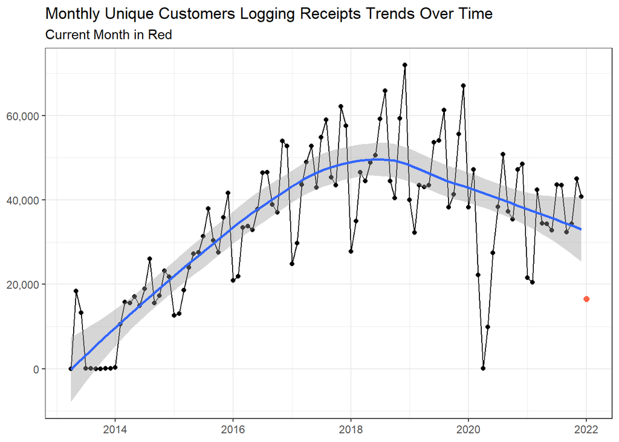

### Monthly View

Each color line represents a different year’s worth of traffic aggregated on a monthly basis.

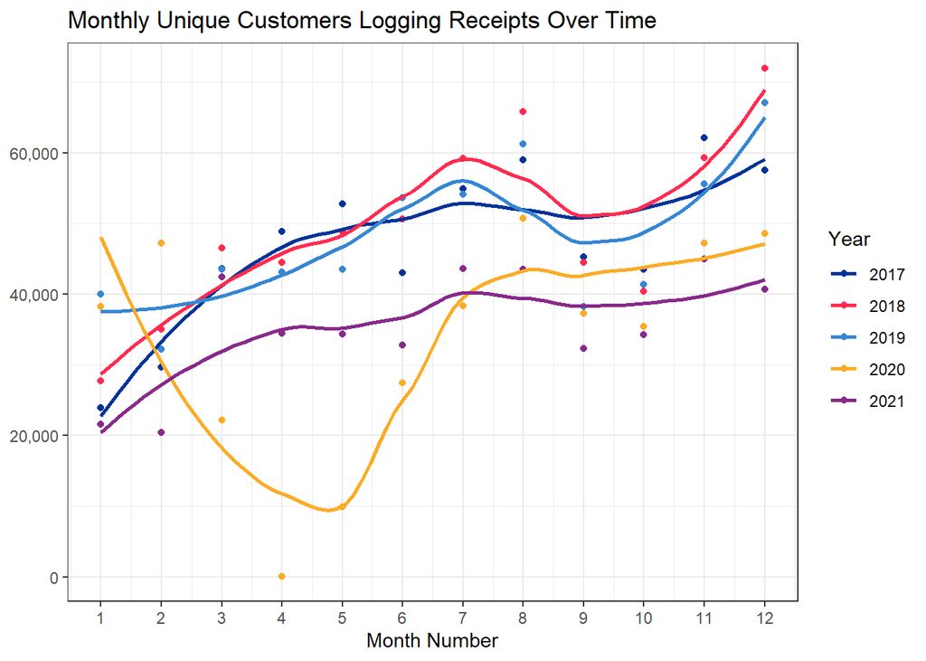

# Forcasting model

## Why Synthetic Controls?

*This method can account for the effects of confounders changing over time, by weighting the control group to better match the treatment group before the intervention. Another advantage of the synthetic control method is that it allows researchers to systematically select comparison groups. It has been applied to the fields of political science, health policy, criminology, and economics.*

In our case, we are using this methodology to help set a baseline of where the business would be if we continue with the same historical processes and procedures as before.

## Step 1: Build Forecast Model

Building model for all entire portfolio.

- In this case, we are already into 2022, but we want to build the forecast model excluding the new year.
- In the future data frame, we go forwards 365 days (1 year) to be able to predict against.

```r
Traffc <-
  CleanRecpts %>%
  filter(Date < as.Date("2022-01-01")) %>%
  mutate(ds = Date) %>%
  group_by(ds) %>%
  summarise(y = sum(UniqCust, na.rm=T)) %>%
  ungroup()

# m <- prophet(Traffc, holidays = covid)
m <- prophet(holidays = covid)
m <- add_country_holidays(m, country_name = 'US')
m <- fit.prophet(m, Traffc)

future <- make_future_dataframe(m, periods = 365)
# tail(future)


forecast <- predict(m, future)
# tail(forecast[c('ds', 'yhat', 'yhat_lower', 'yhat_upper')])
```

## Forecast Results

Below is the forecast model.

We see a strong degree of seasonality

### Forecast Model 1

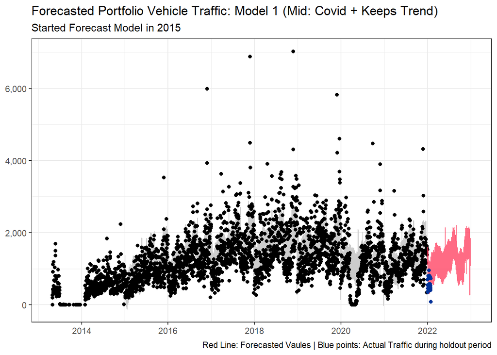

### Forecast Model 2

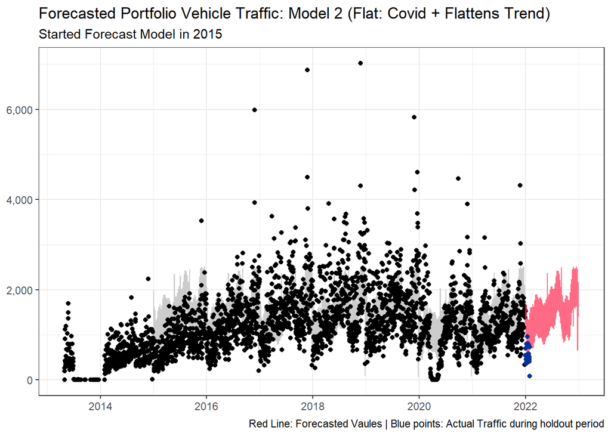

### Forecast Model 3

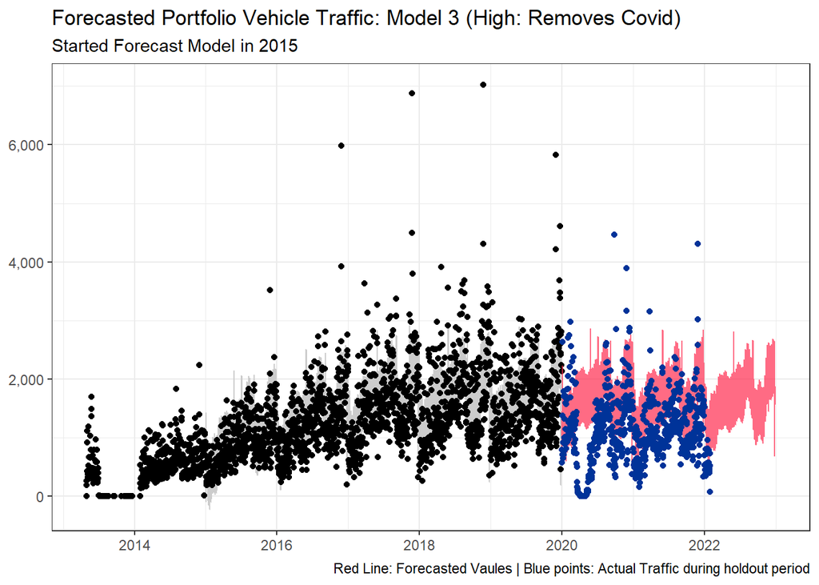

### Forecast Model 4

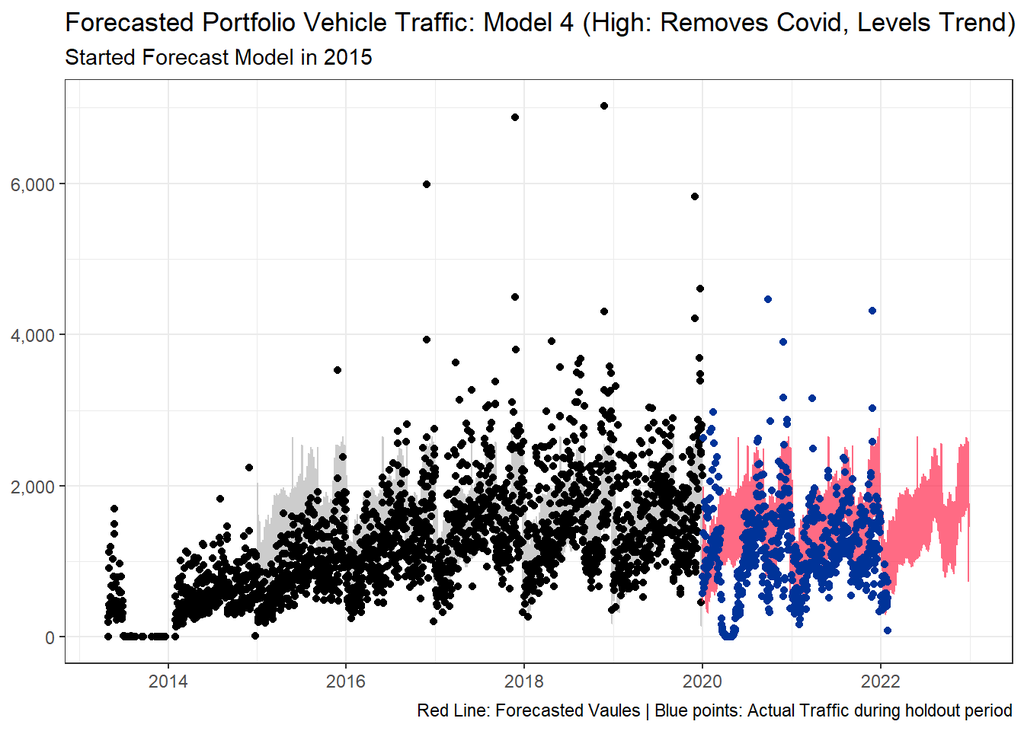

### Forecast Components

A forecast model can be broken up into the different elements that add (or multiply) together. By splitting them out and visualizing them, we then can view the index values and assess the impact of different items on the results

By breaking down the forecast into it’s component parts we see a couple of things:

- Trend: This element shows what the general trend is year over year.
  - In this case, there is a forecasted to be a downwards trend for future years.
- Holidays: This elements flags both the US holidays as well as the date range from 3/1/2020 - 5/1/2021 as the main effect of Covid shutdowns.
- Weekly: This element shows how traffic varies within the week.
  - The outlets being a mainly weekend business really shows up in this view, with the positive indices being for Friday, Saturday, Sunday.
- Yearly: This is the element of the within year seasonality.
  - In general we see that there is a general ramp up throughout the first part of the year, a small lull in October, and then our biggest traffic volumes seen during the end of year.

**Note about negative values:** These 4 items below are added together to create the forecast model. This is why there are some items that are negative and some that are positive. A negative value does not mean that we would forecast negative vehicles, but instead that at those instances the traffic would decrease from the trend.

- An example here would be the impact of Christmas day on digital traffic, where with the centers closed it’s less likely people are logging into the website.
- We do see a yearly spike around Thanksgiving/Black Friday time period.

#### Model 1

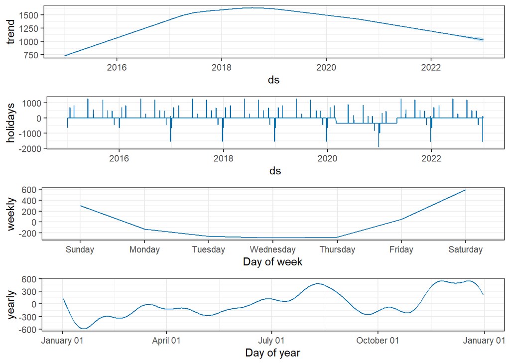

#### Model 2

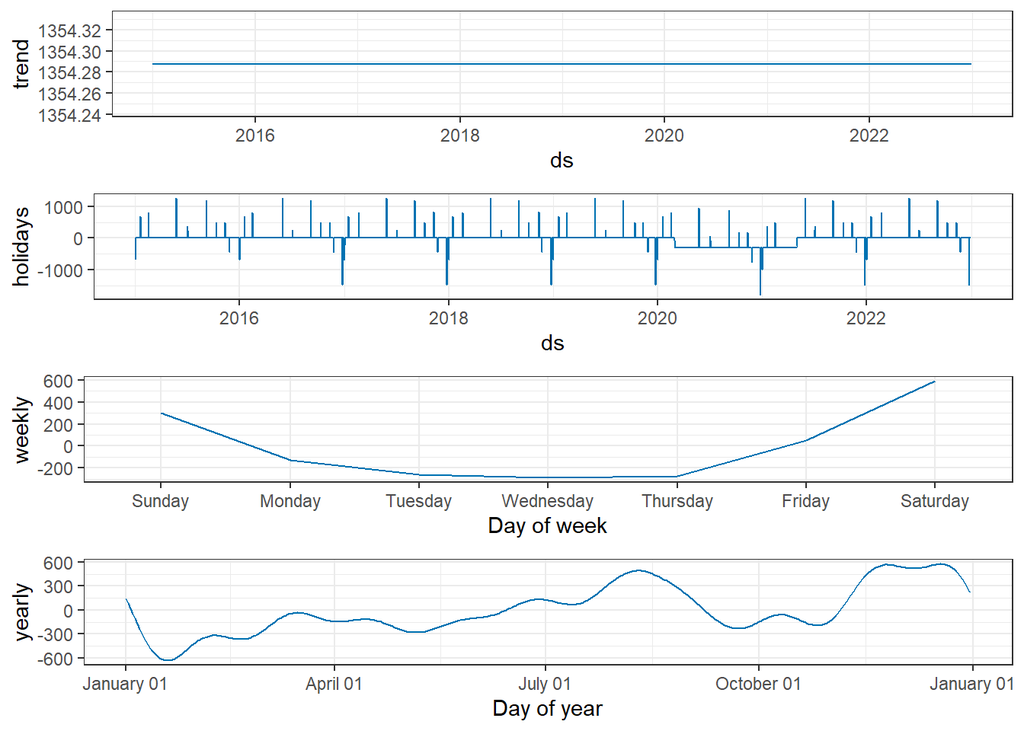

#### Model 3

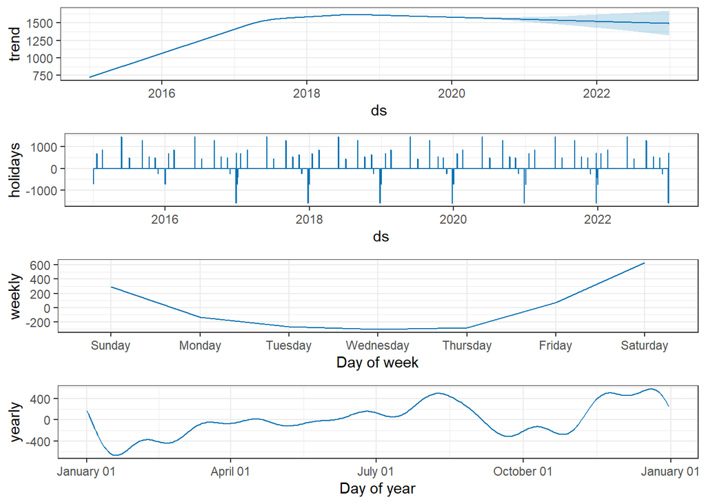

#### Model 4

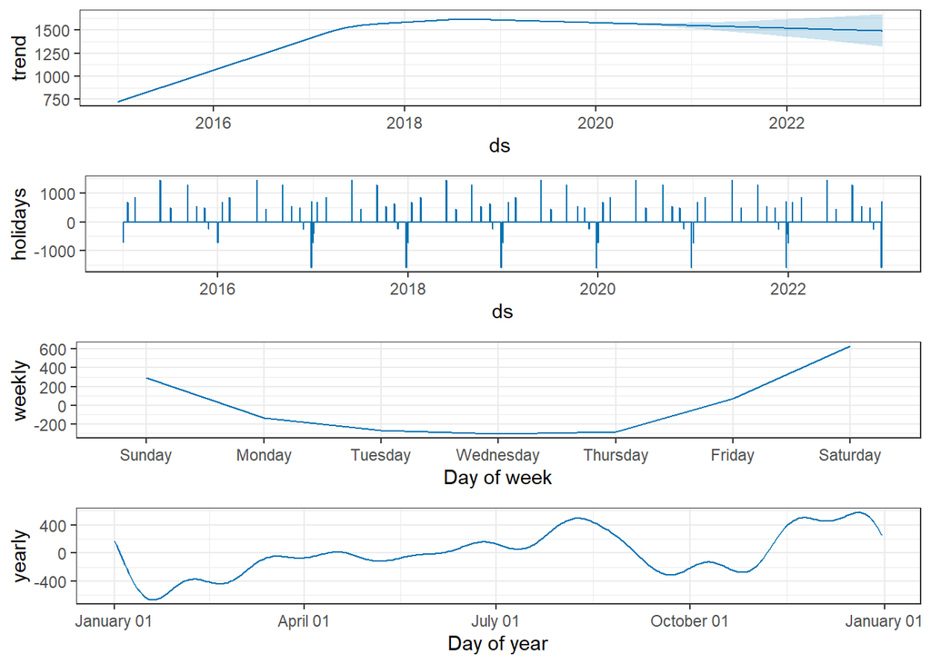

# Next Steps

The “Top Line” section presented both the actuals traffic by month for prior years with the forecasted values for 2022 (bolded).

The forecasted values could represent what would be considered as the baseline for goal setting by the business. Upon which the business leaders responsible for this metric would review and adjust the values according to where they believe they can made an impact. It will be up to the business to determine what strategies they will implement and adjust the goals accordingly.

This analysis body of work is set up to allow for the adjustment of goals based upon the values decided upon by the business owners.

# Appendix

```sql
Select CustomerID, CenterID, TentID, CreatedOn, PurchaseDate, ReceiptAmount, MinsBtwnPurchAndSubmit
    From (
        Select *
            , datediff(minute, PurchaseDate, CreatedOn) as MinsBtwnPurchAndSubmit
        From tblReceiptTracking
        Where Status = 'A'
            And DeletedOn is null
            And TentID != 'TCPTS'
            And TentID is not null
            And TentID != 'OTHER'
            And ReceiptAmount < 100000
    ) a
```

## Forecast Model

The forecast model code is available within the I&A OneDrive.